# ML HW 2 CZ Submission

```python
#Read in data
import pandas as pd
import matplotlib.pyplot as plt
import numpy as np
from statistics import mean
from sklearn.neighbors import KNeighborsRegressor
from sklearn.linear_model import LinearRegression
from sklearn.linear_model import Ridge
from sklearn.linear_model import Lasso
from sklearn.linear_model import LogisticRegression
from sklearn.neighbors import KNeighborsClassifier
from sklearn.model_selection import train_test_split
from sklearn.preprocessing import StandardScaler
from sklearn.model_selection import cross_val_score
from sklearn.model_selection import RepeatedKFold
from sklearn.model_selection import StratifiedKFold
from sklearn.model_selection import KFold
from sklearn.model_selection import GridSearchCV

df = pd.read_csv('Caschool.csv')

#omit "readscr" and "mathscr" using del function
del df['readscr']
del df['mathscr']
```

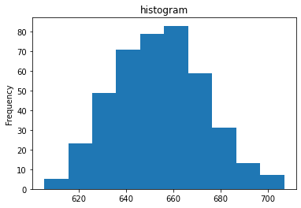

```python
#1.1: Vizualizing univariate distribution of testscr and 3 explanatory variables

#Univariate distribution 1: Test score
df.testscr.plot(kind = 'hist', title = 'histogram')
```

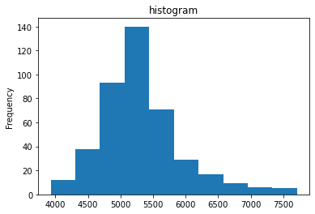

```python
#Explanatory variable 1: expenditure per student
df.expnstu.plot(kind = 'hist', title = 'histogram')
```

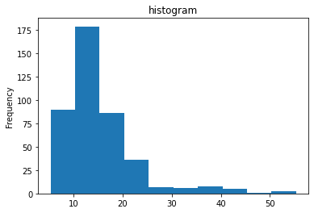

```python
#Explanatory variable 2: district average income
df.avginc.plot(kind = 'hist', title = 'histogram')
```

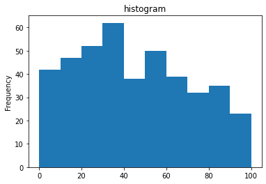

```python
#Explanatory variable 1: % qualifying for reduced price lunch
df.mealpct.plot(kind = 'hist', title = 'histogram')
```

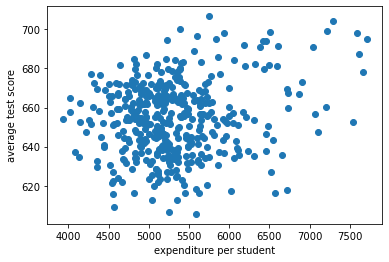

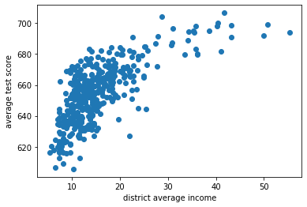

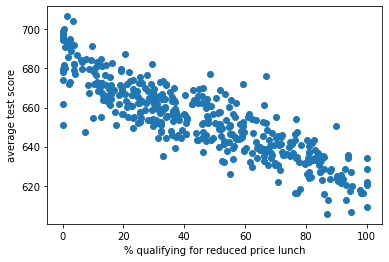

```python
#1.2: Plot each explanatory variable against average test score

#Plot 1: test score and expenditure per student
plt.scatter(df['expnstu'], df['testscr'])
plt.ylabel("average test score")
plt.xlabel('expenditure per student')
plt.show()

#Plot 3: test score and district average income
plt.scatter(df['avginc'], df['testscr'])
plt.ylabel("average test score")
plt.xlabel('district average income')
plt.show()

#Plot 3: test score and percent qualifying for reduced price lunch
plt.scatter(df['mealpct'], df['testscr'])
plt.ylabel("average test score")
plt.xlabel('% qualifying for reduced price lunch')
plt.show()
```

```python
#1.3: Preprocessing, split the data into training/test set, and evaluate the relationship between X variables and testscr using regression models

#omit columns that are continuous Unnamed: 0, county, district, grspan':
#X Data:
x = df[['enrltot','teachers', 'calwpct', 'mealpct', 'computer', 'compstu', 'expnstu', 'str', 'avginc', 'elpct']]
#Y Data:
y = df['testscr']
y = y.astype('int')
print(x.columns) #Print out all variables to work with

#Splitting data into training and test set
x_train, x_test, y_train, y_test = train_test_split(x,y, random_state = 1)

#Preprocessing data using StandardScaler()
scaler = StandardScaler()
scaler.fit(x_train) #scale training data
x_train_scaled = scaler.transform(x_train)
scaler.fit(x_test) #scale testing data
x_test_scaled = scaler.transform(x_test)
```

```
Index(['enrltot', 'teachers', 'calwpct', 'mealpct', 'computer', 'compstu',
       'expnstu', 'str', 'avginc', 'elpct'],
      dtype='object')
```

```python
#REGRESSION MODEL 1: KNN regression

#Get CV Score from TRAINING set
rkfold = RepeatedKFold()

knr = KNeighborsRegressor()

#Model w/Unscaled data
knr.fit(x_train, y_train)
print("Unscaled KNR accuracy: {:.3f}".format(knr.score(x_test, y_test)))

#Get Cross Val Score
print("SV score for KNR RKFold (unscaled):\n{}".format(mean(cross_val_score(knr, x_train, y_train, cv = rkfold, scoring = 'r2')))) #get the avg of all scores

#Model w/Scaled Data
knr.fit(x_train_scaled, y_train)
print("Scaled KNR accuracy: {:.3f}".format(knr.score(x_test_scaled, y_test)))

#Get CV Score
print("CV Score for KNR RKFold (scaled):\n{}".format(mean(cross_val_score(knr, x_train_scaled, y_train, cv = rkfold, scoring = 'r2')))) #get the avg of all scores
```

```
Unscaled KNR accuracy: 0.075
SV score for KNR RKFold (unscaled):
-0.09248840458610308
Scaled KNR accuracy: 0.728
CV Score for KNR RKFold (scaled):
0.7399781417160209
```

```python
#REGRESSION MODEL 2: Linear
lr = LinearRegression()


#Model W/Unscaled data
lr.fit(x_train, y_train)
print("Linear reg. accuracy (Unscaled) : {:.3f}".format(lr.score(x_test, y_test)))
y_pred = lr.predict(x_test)

#Get CV Score
print("""Linear RKFold(Unscaled) CV Score:\n{}""".format(mean(cross_val_score(lr, x_train, y_train, cv = rkfold, scoring = 'r2'))))


#Model w/Scaled Data
lr.fit(x_train_scaled, y_train)
print("Linear reg. accuracy (Scaled): {:.3f}".format(lr.score(x_test_scaled, y_test)))
y_pred = lr.predict(x_test_scaled)

#CV Score w/Scaled data
print("""Linear RKFold(Scaled) CV Score:\n{}""".format(mean(cross_val_score(lr, x_train_scaled, y_train, cv = rkfold, scoring = 'r2'))))
```

```
Linear reg. accuracy (Unscaled) : 0.745
Linear RKFold(Unscaled) CV Score:
0.8110331582396043
Linear reg. accuracy (Scaled): 0.724
Linear RKFold(Scaled) CV Score:
0.8175410720281072
```

```python
#REGRESSION MODEL 3: Ridge
ridge = Ridge(max_iter = 100000)


#Model w/Unscaled data
ridge.fit(x_train, y_train)
print("Ridge reg. accuracy (Unscaled) : {:.3f}".format(ridge.score(x_test, y_test)))

#Get CV Score w/Unscaled data
print("""Ridge KFold(Unscaled) CV Score:\n{}""".format(mean(cross_val_score(ridge, x_train, y_train, cv=rkfold, scoring = 'r2'))))


#Model w/Scaled Data
ridge.fit(x_train_scaled, y_train)
print("Ridge reg. accuracy (Scaled): {:.3f}".format(ridge.score(x_test_scaled, y_test)))

#Get CV score w/Scaled data
print("""Ridge KFold(Scaled) CV Score:\n{}""".format(mean(cross_val_score(ridge, x_train_scaled, y_train, cv=rkfold, scoring = 'r2'))))
```

```
Ridge reg. accuracy (Unscaled) : 0.744
Ridge KFold(Unscaled) CV Score:
0.8124828463733147
Ridge reg. accuracy (Scaled): 0.726
Ridge KFold(Scaled) CV Score:
0.8160072000449309
```

```python
#REGRESSION MODEL 4: Lasso
lasso = Lasso(max_iter = 100000)


#Lasso Model with unscaled data
lasso.fit(x_train, y_train)
print("Lasso reg. accuracy (Unscaled) : {:.3f}".format(lasso.score(x_test, y_test)))

#Get CV Score
print("""Lasso KFold(Unscaled) CV Score:\n{}""".format(mean(cross_val_score(lasso, x_train, y_train, cv=rkfold, scoring = 'r2'))))


#Lasso Model w/scaled Data
lasso.fit(x_train_scaled, y_train)
print("Lasso reg. accuracy (Scaled): {:.3f}".format(lasso.score(x_test_scaled, y_test)))

#Get CV score w/Scaled data
print("""Lasso KFold(Scaled) CV Score:\n{}""".format(mean(cross_val_score(lasso, x_train_scaled, y_train, cv=rkfold, scoring = 'r2'))))
```

```
Lasso reg. accuracy (Unscaled) : 0.743
Lasso KFold(Unscaled) CV Score:
0.8139438224916029
Lasso reg. accuracy (Scaled): 0.717
Lasso KFold(Scaled) CV Score:
0.8113800570055157
```

```python
#1.4: Tune parameters of the models using GridSearchCV
```

```python
#(Unscaled) KNR Gridsearch
param_grid = {'n_neighbors': np.arange(1, 19, 2)} #np.arange creates sequence of numbers for each k value
grid = GridSearchCV(knr, param_grid=param_grid, cv=rkfold)

#Fit Model:
grid.fit(x_train, y_train)

#Get the best CV score, parameters, and test score
print("KNR Best mean cross-validation score: {:.3f}".format(grid.best_score_)) #best_score_ for CV
print("KNR Best parameters: {}".format(grid.best_params_)) #best_params_ for parameters
print("KNR Best test-set score: {:.3f}".format(grid.score(x_test, y_test))) #score for test


#SCALED KNR Gridsearch
param_grid = {'n_neighbors': np.arange(1, 19, 2)} #np.arange creates sequence of numbers for each k value
grid = GridSearchCV(knr, param_grid=param_grid, cv=rkfold)

#Scaled KNR fit
grid.fit(x_train_scaled, y_train)

#Extraction of best scores/parameters on Scaled data
print("Scaled KNR best mean cross-validation score: {:.3f}".format(grid.best_score_))
print("Scaled KNR best parameters: {}".format(grid.best_params_))
print("Scaled KNR test-set score: {:.3f}".format(grid.score(x_test_scaled, y_test)))
```

```
KNR Best mean cross-validation score: -0.006
KNR Best parameters: {'n_neighbors': 17}
KNR Best test-set score: 0.034
Scaled KNR best mean cross-validation score: 0.764
Scaled KNR best parameters: {'n_neighbors': 15}
Scaled KNR test-set score: 0.707
```

```python
#Ridge Gridsearch
alpha = {'alpha': np.arange(0, 20, 0.1)} #np.arange creates sequence of numbers for each k value
grid = GridSearchCV(ridge, param_grid=alpha, cv=rkfold)

#(Unscaled) fit
grid.fit(x_train, y_train)

#Extract best score and parameters
print("(Unscaled) Ridge best mean cross-validation score: {:.3f}".format(grid.best_score_))
print("(Unscaled) Ridge best parameters: {}".format(grid.best_params_))
print("(Unscaled) Ridge test-set score: {:.3f}".format(grid.score(x_test, y_test)))

#Scaled Ridge Gridsearch
grid = GridSearchCV(ridge, param_grid=alpha, cv=rkfold)

#Scaled fit
grid.fit(x_train_scaled, y_train)

#Extract best score and parameters for scaled data
print("Scaled Ridge best mean cross-validation score: {:.6f}".format(grid.best_score_))
print("Scaled Ridge best parameters: {}".format(grid.best_params_))
print("Scaled Ridge test-set score: {:.3f}".format(grid.score(x_test_scaled, y_test)))
```

```
(Unscaled) Ridge best mean cross-validation score: 0.817
(Unscaled) Ridge best parameters: {'alpha': 19.900000000000002}
(Unscaled) Ridge test-set score: 0.743
Scaled Ridge best mean cross-validation score: 0.816593
Scaled Ridge best parameters: {'alpha': 8.0}
Scaled Ridge test-set score: 0.726
```

```python
#Lasso Gridsearch
grid = GridSearchCV(lasso, param_grid=alpha, cv=rkfold)

#use meta model methods to fit score and predict model:
grid.fit(x_train, y_train)

#extract best score and parameter by calling objects "best_score_" and "best_params_"
print("Lasso best mean cross-validation score: {:.3f}".format(grid.best_score_))
print("Lasso best parameters: {}".format(grid.best_params_))
print("Lasso test-set score: {:.3f}".format(grid.score(x_test, y_test)))

#Scaled Lasso Gridsearch
grid = GridSearchCV(lasso, param_grid=alpha, cv=rkfold)

#use meta model methods to fit score and predict model:
grid.fit(x_train_scaled, y_train)

#extract best score and parameter by calling objects "best_score_" and "best_params_"
print("Scaled Lasso best mean CV score: {:.6f}".format(grid.best_score_))
print("Scaled Lasso best parameters: {}".format(grid.best_params_))
print("Scaled Lasso test-set score: {:.3f}".format(grid.score(x_test_scaled, y_test)))
```

[output not shown]

[output cut: 245 more lines]

[output not shown]

```
Lasso best mean cross-validation score: 0.818
Lasso best parameters: {'alpha': 1.0}
Lasso test-set score: 0.743
```

[output not shown]

[output cut: 245 more lines]

[output not shown]

```
Scaled Lasso best mean CV score: 0.817350
Scaled Lasso best parameters: {'alpha': 0.2}
Scaled Lasso test-set score: 0.727
```

The best scoring model that was run under Gridsearch CV was the Lasso regression using unscaled data, giving us an alpha of 1 and a CV score of 0.818 and a test score of 0.743. The second best model based on the CV scores was an unscaled ridge regression w/a CV score of 0.817 and a test score of .743, but gives us a higher penalty of alpha = 19.9.

```python
#1.5: Comparing the coefficients of the 2 best linear models

#Scaled Ridge Regression
ridge = Ridge(alpha = 9.4).fit(x_train_scaled, y_train) #default w/alpha of 1, then fit the training data
print("Scaled Ridge Training set score: {:.5f}".format(ridge.score(x_train_scaled, y_train))) #scoring on training data
print("Scaled Ridge Test set score: {:.25}".format(ridge.score(x_test_scaled, y_test))) #scoring on testing data

print("ridge.coef_: {}".format(ridge.coef_))


#Scaled Lasso Regression
lasso = Lasso(alpha = 0.2, max_iter = 100000).fit(x_train_scaled, y_train) #default w/alpha of 1, then fit the training data
print("Scaled Lasso Training set score: {:.5f}".format(lasso.score(x_train_scaled, y_train))) #scoring on training data
print("Scaled Lasso Test set score: {:.5f}".format(lasso.score(x_test_scaled, y_test))) #scoring on testing data

print("lasso.coef_: {}".format(lasso.coef_))
```

```
Scaled Ridge Training set score: 0.83200
Scaled Ridge Test set score: 0.7263645922451378300621627
ridge.coef_: [-0.13421632 -0.67754206 -1.44855402 -9.31404662  0.91415881  0.47715732
  1.21336004 -0.31022506  3.94642534 -4.26813271]
Scaled Lasso Training set score: 0.83183
Scaled Lasso Test set score: 0.72669
lasso.coef_: [ -0.          -0.          -0.71810834 -10.45795765   0.
   0.534846     1.09242623  -0.18185815   3.72829814  -3.77618953]
```

Both models believe that enrollment total and teachers, and student teacher ratio are not significant indicators. However, the ridge model was able to show that the computers predictor was more significant than teachers, which was more significant than the enrollment total.

Both agree that what was significant was the percent that was qualifying on reduced lunch was a strong indicator of a lower test score, and an average income was a strong indicator of a positive test score. A strong negative indicator in both models was the percent of english learners - more english learners meant a lower average test score.

Below is a more detailed list of what the two models agreed upon, and how significant/insignificant each coefficient was according to their model, and the direction of the relationship.

- Enrollment total (-): Agree, insignificant
- Teachers (-): Agree, insignificant *but the ridge views this as more significant than the enrollment total
- % qualifying for cal works (-): Somewhat agree, semi-insignificant, but the lasso regression treats as even more insignificant
- % qualifying for reduced lunch (-): Agree, very significant
- Computers (+): somewhat agree - lasso sets it to 0 but ridge sets it to 0.9, so ridge might think its more significant than lasso
- Computers per student (+): agree, insignificant
- Expenses per student (+): Agree, semi-significant
- Student teacher ratio (-): Agree, insignificant
- Average income (+): Agree, significant
- Percent of English learners (-): Agree, significant, *but lasso treats it as less significant than the ridge

**Question 1.6**

I believe that the model I would choose overall is the lasso with scaled data, because both the test scores and the cross validation scores of the lasso was greater than that of the ridge. Moreover, because there are so many features in this model, variable selection would be prefered. the lasso model does variable selection - completely zero-ing out insignificant predictors - while still reducing overfitting.

```python
#read in both datasets
whitedf = pd.read_csv('winequality-white.csv', sep = ';')
reddf = pd.read_csv('winequality-red.csv', sep = ';')

#Add column called winetype to each seperate df, (red = 1, white = 0, but will be binary once merged)
whitedf['winetype'] = 0
reddf['winetype'] = 1

whitedf.head()
print(x.columns)
```

[output not shown]

```python
#combine both datasets using pandaas concat
df = pd.concat([whitedf, reddf], axis = 0)
df.columns = df.columns.str.replace(' ','_') #swap space for underline in variable names
```

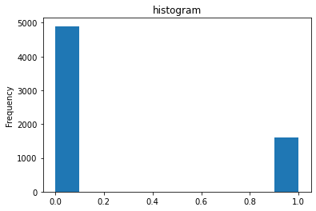

```python
#2.1: Univariate Distribution of target variable and 3 explanatory variables

#Distribution of wine type (target variable)
df.winetype.plot(kind = 'hist', title = 'histogram')
```

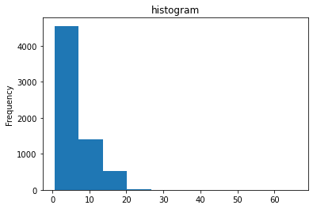

```python
#Explanatory variable 1: sugar content
df.residual_sugar.plot(kind = 'hist', title = 'histogram')
```

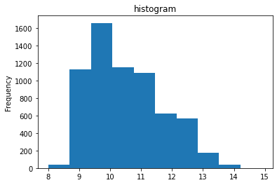

```python
#Explanatory variable 2: Distribution of alcohol content
df.alcohol.plot(kind = 'hist', title = 'histogram')
```

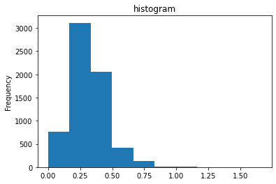

```python
#Explanatory Variable 3: Distribution of citric acid
df.citric_acid.plot(kind = 'hist', title = 'histogram')
```

```python
#2.2
#Split data into target and explanatory variables
y = df['winetype']
x = df.loc[:, df.columns != 'winetype']

#Splitting data into training and test set
x_train, x_test, y_train, y_test = train_test_split(x,y, random_state = 0)

#Scale Data
scaler.fit(x_train) #scale training data
x_train_scaled = scaler.transform(x_train)
scaler.fit(x_test) #scale testing data
x_test_scaled = scaler.transform(x_test)
```

```python
#Build non-penalized logistic regression model
log = LogisticRegression(penalty = 'none', tol = 0.01, max_iter = 100000)
log.fit(x_train, y_train)

print("logreg .coef_: {}".format(log.coef_))


#Score test/training data using unscaled data
print("Non-penalized Log Unscaled Training set score: {:.3f}".format(log.score(x_train, y_train)))
print("Non-penalized Log Unscaled Test set score: {:.3f}".format(log.score(x_test, y_test)))

#Get CV Score w/skfold
skfold = StratifiedKFold() #Set up parameters for CV Score
print("""LogReg SKFold Unscaled CV Score:\n{}""".format(mean(cross_val_score(log, x_train, y_train, cv=skfold, scoring = 'accuracy')))) #for log regressions, always set scoring = to accuracy

#Score test/training data using scaled data
log.fit(x_train_scaled, y_train)
print("Non-penalized Log Scaled Training set score: {:.3f}".format(log.score(x_train_scaled, y_train)))
print("Non-penalized Log Scaled Test set score: {:.3f}".format(log.score(x_test_scaled, y_test)))


#Get CV Score for scaled data
print("""Non-penalized LogReg SKFold Scaled CV Score:\n{}""".format(mean(cross_val_score(log, x_train_scaled, y_train, cv=skfold, scoring = 'accuracy'))))
```

```
logreg .coef_: [[-1.45704942e-01  7.15447500e+00 -2.82337146e+00 -9.56803641e-01
   2.54441436e+01  6.34272137e-02 -5.47941494e-02  1.57488429e+03
   2.61300541e-01  3.51755801e+00  1.35495439e+00  4.20353420e-01]]
Non-penalized Log Unscaled Training set score: 0.994
Non-penalized Log Unscaled Test set score: 0.994
LogReg SKFold Unscaled CV Score:
0.988298636339704
Non-penalized Log Scaled Training set score: 0.994
Non-penalized Log Scaled Test set score: 0.994
Non-penalized LogReg SKFold Scaled CV Score:
0.9930207971357868
```

```python
#Penalized log

#Build a model for log w/L2 penalty on unscaled data
logl2 = LogisticRegression(penalty = 'l2', tol = 0.0001, max_iter = 100000000)
logl2.fit(x_train, y_train)
print("log12.coef_: {}".format(logl2.coef_))

print("LogReg L2 Unscaled Training set score: {:.3f}".format(logl2.score(x_train, y_train)))
print("LogReg L2 Unscaled Test set score: {:.3f}".format(logl2.score(x_test, y_test)))

#predict values based on test data
predicted_vals = logl2.predict(x_test) # y_pred includes predictions
print("log12.predict: {}".format(predicted_vals))

#Build a model for log w/L2 penalty on SCALED data
logl2scaled = LogisticRegression(penalty = 'l2').fit(x_train_scaled, y_train)

print("log.coef_: {}".format(logl2.coef_))


print("LogReg L2 Scaled Training set score: {:.5f}".format(logl2scaled.score(x_train_scaled, y_train)))
print("LogReg L2 Scaled Test set score: {:.5f}".format(logl2scaled.score(x_test_scaled, y_test)))

#predict values based on test data
predicted_vals = logl2scaled.predict(x_test_scaled) # y_pred includes predictions
print("log.predict: {}".format(predicted_vals))
```

```
log12.coef_: [[ 1.15560986e+00  7.98430816e+00 -9.56646372e-01 -1.00140990e-01
   2.74003659e+00  4.29816285e-02 -5.69026866e-02  2.16780331e-01
   5.89497984e+00  5.55773078e+00 -4.99116686e-01  3.97173483e-03]]
LogReg L2 Unscaled Training set score: 0.985
LogReg L2 Unscaled Test set score: 0.986
log12.predict: [1 1 0 ... 0 0 1]
log.coef_: [[ 1.15560986e+00  7.98430816e+00 -9.56646372e-01 -1.00140990e-01
   2.74003659e+00  4.29816285e-02 -5.69026866e-02  2.16780331e-01
   5.89497984e+00  5.55773078e+00 -4.99116686e-01  3.97173483e-03]]
LogReg L2 Scaled Training set score: 0.99323
LogReg L2 Scaled Test set score: 0.99508
log.predict: [1 1 0 ... 0 0 1]
```

```python
#set up parameters for CV Score

#Get CV Score for log w/l2 penalty on unscaled data
print("""LogReg l2 SKFold(Unscaled) CV Score:\n{}""".format(mean(cross_val_score(logl2, x_train, y_train, cv=skfold, scoring = 'accuracy'))))
#Get CV Score on scaled data
print("""LogReg l2 SKFold(Scaled) CV Score:\n{}""".format(mean(cross_val_score(logl2scaled, x_train_scaled, y_train, cv=skfold, scoring = 'accuracy'))))
```

```
LogReg l2 SKFold(Unscaled) CV Score:
0.983987995577318
LogReg l2 SKFold(Scaled) CV Score:
0.993225925340915
```

```python
#KNN for classification
knn = KNeighborsClassifier()

#Building a KNN model for unscaled data
knn.fit(x_train, y_train)

#Print accuracy rounded to two digits to the right of decimal
print("KNN Unscaled accuracy: {:.3f}".format(knn.score(x_test, y_test)))
print("KNN Predictions", knn.predict(x_test))

#Evaluate model w/CV score using unscaled data
print("KNN Unscaled SKFold CV Score:\n{}".format(
mean(cross_val_score(knn, x_train, y_train, cv=skfold, scoring = "accuracy"))))


#Build a KNN model for scaled data
knn.fit(x_train_scaled, y_train)

#Print accuracy rounded to two digits to the right of decimal
print("KNN Scaled accuracy: {:.3f}".format(knn.score(x_test_scaled, y_test)))
y_pred = knn.predict(x_test_scaled)


#Using KNN Cross Val on scaled data
print("KNN Scaled SKFold CV Score:\n{}".format(
mean(cross_val_score(knn, x_train_scaled, y_train, cv=skfold, scoring = 'accuracy'))))
```

```
KNN Unscaled accuracy: 0.935
KNN Predictions [1 0 0 ... 0 0 1]
KNN Unscaled SKFold CV Score:
0.9392430895593114
KNN Scaled accuracy: 0.993
KNN Scaled SKFold CV Score:
0.9936368135628916
```

For the unpenalized logistic regression, the CV score also improves after scaling, and the difference is only .005. The accuracy test scores, however, remain approximately the same (0.994).

For penalized logistic regression, the StandardScaler improved the CV score by 0.01, and scaling improved the test score by 0.009.

Because the CV scores were higher for the scaled models than the unscaled models, I will choose to use scaled data for gridsearching in 2.3.

```python
#2.3: GridSearchCV

#Gridsearch CV Function
def gridsearch(model, parameter, cv_param, x_train_param, x_test_param):
    grid = GridSearchCV(model, param_grid = parameter, cv = cv_param, scoring = "accuracy")

    #use meta model methods to fit score and predict model:
    grid.fit(x_train_param, y_train)

    #extract best score and parameter by calling objects "best_score_" and "best_params_"
    print("Best mean cross-validation score: {:.3f}".format(grid.best_score_))
    print("Best parameters: {}".format(grid.best_params_))
    print("Best test score: {:.3f}".format(grid.score(x_test_param, y_test)))
```

```python
#Gridsearch on (Scaled) Log regression:
gridsearch(LogisticRegression(), {"C":np.arange(0,100,1), "penalty":["l1","l2", "none"]}, skfold, x_train_scaled, x_test_scaled)
```

[output not shown]

[output cut: 2318 more lines]

[output not shown]

```
Best mean cross-validation score: 0.993
Best parameters: {'C': 1, 'penalty': 'l2'}
Best test score: 0.995
```

```python
#Gridsearch on (Scaled) KNN:
gridsearch(knn, {'n_neighbors': np.arange(1, 19, 2)}, skfold, x_train_scaled, x_test_scaled)
```

[output not shown]

*Question 2.4*

```python
#2.4:
#Change CV to Kfold + Shuffling for gridsearching
kfold = KFold(shuffle = True)
#Gridsearch CV w/Log Regression and kfold:
gridsearch(log, {"C":np.arange(0,100,1), "penalty":["l1","l2", 'none']}, kfold, x_train_scaled, x_test_scaled)
#KNN Gridsearch on new randomstate
gridsearch(knn, {'n_neighbors': np.arange(1, 19, 2)}, skfold, x_train_scaled, x_test_scaled)
```

[output not shown]

[output cut: 2320 more lines]

[output not shown]

```
Best mean cross-validation score: 0.995
Best parameters: {'C': 27, 'penalty': 'l2'}
Best test score: 0.994
Best mean cross-validation score: 0.993
Best parameters: {'n_neighbors': 1}
Best test score: 0.993
```

```python
#Change random seed in KFold for gridsearching
kfold = KFold(shuffle = True, random_state = 20)
#Gridsearch CV w/Log Regression and kfold:
gridsearch(log, {"C":np.arange(0,100,1), "penalty":["l1","l2", 'none']}, kfold, x_train_scaled, x_test_scaled)
#KNN Gridsearch on new randomstate
gridsearch(knn, {'n_neighbors': np.arange(1, 19, 2)}, skfold, x_train_scaled, x_test_scaled)
```

[output not shown]

[output cut: 2320 more lines]

[output not shown]

```
Best mean cross-validation score: 0.995
Best parameters: {'C': 7, 'penalty': 'l2'}
Best test score: 0.994
Best mean cross-validation score: 0.993
Best parameters: {'n_neighbors': 1}
Best test score: 0.993
```

```python
#Change random state from 0 to 100
#Splitting data into training and test set
x_train, x_test, y_train, y_test = train_test_split(x,y, random_state = 100)

#Scale new data
scaler.fit(x_train) #scale training data
x_train_scaled = scaler.transform(x_train)
scaler.fit(x_test) #scale testing data
x_test_scaled = scaler.transform(x_test)

#Log Gridsearch on new randomstate
gridsearch(LogisticRegression(), {"C":np.arange(0,100,1), "penalty":["l1","l2", 'none']}, kfold, x_train_scaled, x_test_scaled)

#KNN Gridsearch on new randomstate
gridsearch(knn, {'n_neighbors': np.arange(1, 19, 2)}, skfold, x_train_scaled, x_test_scaled)
```

[output not shown]

[output cut: 2320 more lines]

[output not shown]

```
Best mean cross-validation score: 0.995
Best parameters: {'C': 11, 'penalty': 'l2'}
Best test score: 0.994
Best mean cross-validation score: 0.993
Best parameters: {'n_neighbors': 1}
Best test score: 0.993
```

```python
#2.5: Comparing the coefficients of Logistic Regression and Penalized Logistic Regression

#Logistic Regression
logfinal = LogisticRegression(penalty = 'none').fit(x_train_scaled, y_train)
print("Scaled LogReg Training set score: {:.5f}".format(logfinal.score(x_train_scaled, y_train)))
print("Scaled LogReg Test set score: {:.5f}".format(logfinal.score(x_test_scaled, y_test)))

print("logfinal.coef_: {}".format(logfinal.coef_))
```

```
Scaled LogReg Training set score: 0.99528
Scaled LogReg Test set score: 0.99446
logfinal.coef_: [[-1.62232726  1.05347293 -0.48528095 -5.66793396  0.84232933  1.39084668
  -3.60033328  8.47239355 -1.11564677  0.17600231  3.96253774  0.32609628]]
```

```python
#Penalized Logistic Regression
logl2 = LogisticRegression(C = 1, penalty = 'l2').fit(x_train_scaled, y_train)
print("Penalized LogReg Training set score: {:.5f}".format(logl2.score(x_train_scaled, y_train)))
print("Penalized LogReg Test set score: {:.5f}".format(logl2.score(x_test_scaled, y_test)))

print("logl2.coef_: {}".format(logl2.coef_))
```

```
Penalized LogReg Training set score: 0.99425
Penalized LogReg Test set score: 0.99446
logl2.coef_: [[-0.24281954  1.23223937 -0.37144046 -3.00285051  0.79899728  0.75850431
  -2.92358465  4.73533557 -0.08465371  0.55728976  1.90313259  0.26609945]]
```

Both the penalized and non-penalized logistic regressions have the same test score of 0.99446. And both classification models approximately treat each coefficient with the same significance, with residual sugar (less for red wines), alcohol (more for reds), and density (more for reds) being the most significant. For both models, red wine has less sugar, but a higher density and higher alcohol content. The difference between the 2 models, however, is that the penalized log regression constrains the coefficients, so all of the coefficients in the penalized model is smaller/tighter than the unpenalized in almost all instances.

An interesting thing to note is the penalized regression also weights the volatile acidity and sulfates more strongly than the unpenalized regression - red wines have more sulphates and more volatile acidity than white.